# Final Project Practical Machine Learning

Gurjot Singh

21 6 2020

## Executive Summary

Using devices such as Jawbone Up, Nike FuelBand, and Fitbit it is now possible to collect a large amount of data about personal activity relatively inexpensively. These type of devices are part of the quantified self movement - a group of enthusiasts who take measurements about themselves regularly to improve their health, to find patterns in their behavior, or because they are tech geeks. One thing that people regularly do is quantify how much of a particular activity they do, but they rarely quantify how well they do it.

The goal of this project is to use data from accelerometers on the belt, forearm, arm, and dumbell of 6 participants and to predict the manner in which they did the exercise.

The participants were asked to perform barbell lifts correctly and incorrectly in 5 different ways. More information is available from the website here: http://groupware.les.inf.puc-rio.br/har (see the section on the Weight Lifting Exercise Dataset).

## Data

The training data for this project are available here: https://d396qusza40orc.cloudfront.net/predmachlearn/pml-training.csv

The test data are available here: https://d396qusza40orc.cloudfront.net/predmachlearn/pml-testing.csv

The data for this project come from this source: http://groupware.les.inf.puc-rio.br/har.

### Download and read in the data

```r
#Read in the training and testing data
trainingURL <- "http://d396qusza40orc.cloudfront.net/predmachlearn/pml-training.csv"
testingURL <- "http://d396qusza40orc.cloudfront.net/predmachlearn/pml-testing.csv"

trainingData <- read.csv(url(trainingURL), na.strings=c("NA","#DIV/0!",""))
testingData <- read.csv(url(testingURL), na.strings=c("NA","#DIV/0!",""))
```

### Cleanup the data by removing unnecessary columns and ones with many NAs

```r
library(caret)
library(randomForest)
#Remove first 7 columns
trainingData <- trainingData[-c(1:7)]
testingData <- testingData[-c(1:7)]

#colSums(is.na(trainingData)) shows columns either have 0 NAs or many NAs
#so remove all training and testing columns with more than 1 NA
removeCol <- names(trainingData[, colSums(is.na(trainingData)) > 0])
trainingData <- trainingData[, -which(names(trainingData) %in% removeCol)]
testingData <- testingData[, -which(names(testingData) %in% removeCol)]

#Check that the column names (excl last column) are the same in both sets
trainingNames <- colnames(trainingData)
testingNames <- colnames(testingData)
all.equal(trainingNames[1:length(trainingNames)-1], testingNames[1:length(testingNames)-1])
```

```
## [1] TRUE
```

### Setup data, one set for training and one for cross validation

```r
set.seed(33833)
trainIndex <- createDataPartition(trainingData$classe, p=0.6, list=FALSE)
training <- trainingData[trainIndex, ]
testing <- trainingData[-trainIndex, ]
dim(training)
```

```
## [1] 11776    53
```

```r
dim(testing)
```

```
## [1] 7846   53
```

**First try Generalized Boosted Regression (GBM) on the training set and then use the model on the second part of the data for cross validation**

```r
library(gbm)
```

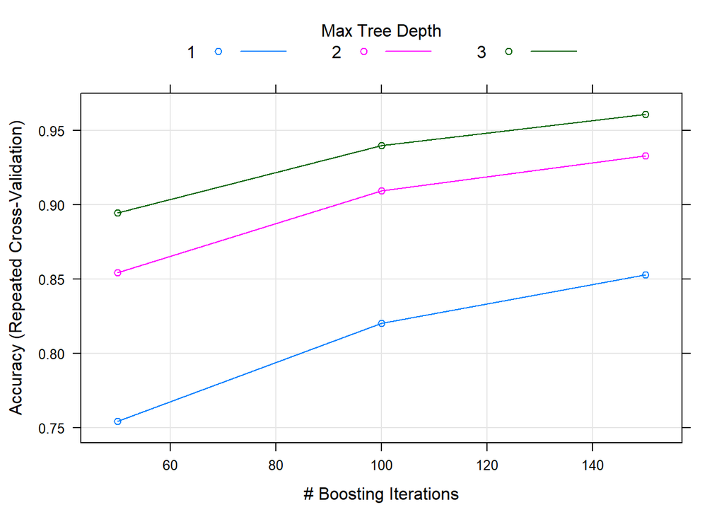

```r
set.seed(33833)
modGBM <- train(classe ~ ., data=training, method="gbm", verbose=FALSE,
                trControl=trainControl(method="repeatedcv",
                                       number=5,
                                       repeats=1))
#modGBM
plot(modGBM)
```

```r
#Use the created model to predict "classe" in the "testing" subset
predictions <- predict(modGBM, testing)
#View the confusion matrix to see the accuracy of the model
confusionMatrix(predictions, testing$classe)
```

```
## Confusion Matrix and Statistics
##
##           Reference
## Prediction    A    B    C    D    E
##          A 2195   55    0    2    0
##          B   21 1416   38    0   16
##          C   13   44 1318   46    7
##          D    1    0   10 1223   19
##          E    2    3    2   15 1400
##
## Overall Statistics
##
##                Accuracy : 0.9625
##                  95% CI : (0.9581, 0.9666)
##     No Information Rate : 0.2845
##     P-Value [Acc > NIR] : < 2.2e-16
##
##                   Kappa : 0.9526
##
##  Mcnemar's Test P-Value : NA
##
## Statistics by Class:
##
##                      Class: A Class: B Class: C Class: D Class: E
## Sensitivity            0.9834   0.9328   0.9635   0.9510   0.9709
## Specificity            0.9898   0.9881   0.9830   0.9954   0.9966
## Pos Pred Value         0.9747   0.9497   0.9230   0.9761   0.9845
## Neg Pred Value         0.9934   0.9839   0.9922   0.9904   0.9935
## Prevalence             0.2845   0.1935   0.1744   0.1639   0.1838
## Detection Rate         0.2798   0.1805   0.1680   0.1559   0.1784
## Detection Prevalence   0.2870   0.1900   0.1820   0.1597   0.1812
## Balanced Accuracy      0.9866   0.9605   0.9732   0.9732   0.9837
```

**Note accuracy is 96.25%, thus the expected out of sample error is 3.75%**

**Next try Random Forest on the training set and then use the model on the second part of the data for cross validation**

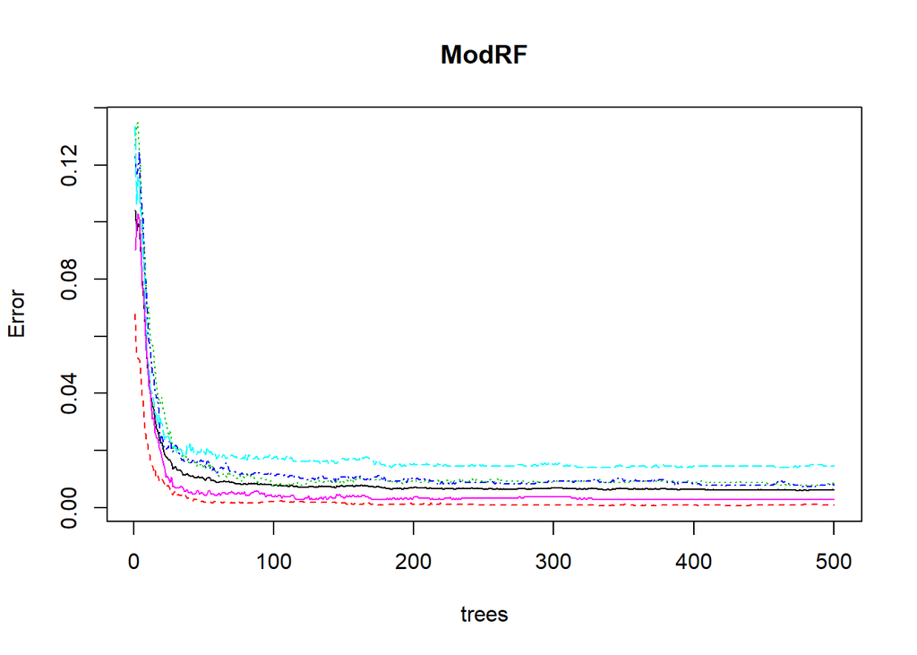

```r
set.seed(33833)
ModRF <- randomForest(classe ~. , data=training)
#ModRF
plot(ModRF)
```

```r
#Use the created model to predict "classe" in the "testing" subset
predictions <- predict(ModRF, testing, type = "class")
#View the confusion matrix to see the accuracy of the model
confusionMatrix(predictions, testing$classe)
```

```
## Confusion Matrix and Statistics
##
##           Reference
## Prediction    A    B    C    D    E
##          A 2229    7    0    0    0
##          B    3 1507    9    0    0
##          C    0    4 1359   17    1
##          D    0    0    0 1267    1
##          E    0    0    0    2 1440
##
## Overall Statistics
##
##                Accuracy : 0.9944
##                  95% CI : (0.9925, 0.9959)
##     No Information Rate : 0.2845
##     P-Value [Acc > NIR] : < 2.2e-16
##
##                   Kappa : 0.9929
##
##  Mcnemar's Test P-Value : NA
##
## Statistics by Class:
##
##                      Class: A Class: B Class: C Class: D Class: E
## Sensitivity            0.9987   0.9928   0.9934   0.9852   0.9986
## Specificity            0.9988   0.9981   0.9966   0.9998   0.9997
## Pos Pred Value         0.9969   0.9921   0.9841   0.9992   0.9986
## Neg Pred Value         0.9995   0.9983   0.9986   0.9971   0.9997
## Prevalence             0.2845   0.1935   0.1744   0.1639   0.1838
## Detection Rate         0.2841   0.1921   0.1732   0.1615   0.1835
## Detection Prevalence   0.2850   0.1936   0.1760   0.1616   0.1838
## Balanced Accuracy      0.9987   0.9954   0.9950   0.9925   0.9992
```

**Note accuracy is 99.44%, thus the expected out of sample error is 0.56%**

### Random Forest will be used on the testing data as it has produced a better result than GBM

## Use Random Forest on the testing data set

```r
dim(testingData)
```

```
## [1] 20 53
```

```r
predictionsTD <- predict(ModRF, testingData, type = "class")
predictionsTD
```

```
##  1  2  3  4  5  6  7  8  9 10 11 12 13 14 15 16 17 18 19 20
##  B  A  B  A  A  E  D  B  A  A  B  C  B  A  E  E  A  B  B  B
## Levels: A B C D E
```